# Kaspersky Data Part one: compilation and pre-processing

Next, we can plot the data for a randomly chosen country, to view the daily pattern and find missing dates.

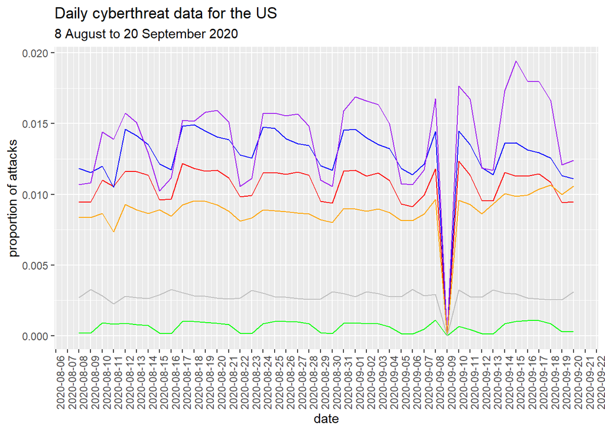

```r
# daily.filtered <- daily.filtered[order(daily.filtered$country),]

us <- daily.filtered[daily.filtered$country == 'United States of America',]

# Note: spam is not displayed in this graph because the spam values are much higher than all the rest of the cyberthreats.
ggplot() +
  geom_line(data = us, aes(x = date, y = local_infection), color = "red") +
  geom_line(data = us, aes(x = date, y = ondemand_scan), color = "blue") +
  geom_line(data = us, aes(x = date, y = malicious_mail), color = "green") +
  geom_line(data = us, aes(x = date, y = network_attack), color = "purple") +
  geom_line(data = us, aes(x = date, y = web_threat), color = "orange") +
  geom_line(data = us, aes(x = date, y = vulnerabilities), color = "grey") +
  # geom_line(data = us, aes(x = date, y = spam), color = "brown") +
  xlab('date') +
  ylab('proportion of attacks') +
  scale_x_date(date_breaks = "1 day") +
  labs(title="Daily cyberthreat data for the US", subtitle="8 August to 20 September 2020") +
  theme(axis.text.x=element_text(angle=90, hjust=1), legend.position="right")
```

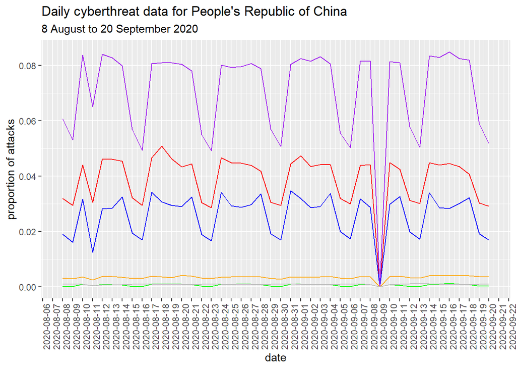

```r
china <- daily.filtered[daily.filtered$country == "People's Republic of China",]

ggplot() +
  geom_line(data = china, aes(x = date, y = local_infection), color = "red") +
  geom_line(data = china, aes(x = date, y = ondemand_scan), color = "blue") +
  geom_line(data = china, aes(x = date, y = malicious_mail), color = "green") +
  geom_line(data = china, aes(x = date, y = network_attack), color = "purple") +
  geom_line(data = china, aes(x = date, y = web_threat), color = "orange") +
  geom_line(data = china, aes(x = date, y = vulnerabilities), color = "grey") +
  # geom_line(data = china, aes(x = date, y = spam), color = "brown") +
  xlab('date') +
  ylab('proportion of attacks') +
  labs(title="Daily cyberthreat data for People's Republic of China", subtitle="8 August to 20 September 2020") +
  scale_x_date(date_breaks = "1 day") +
  theme(axis.text.x=element_text(angle=90, hjust=1), legend.position="right")
```

As shown by the dip in the graph, there is no data on 9 September 2020 as the Kaspersky website was not updated on this date. We would need to impute data for 9 September.

There is also a dip in values on 10-11 August, because the Kaspersky website showed no values for a period of a few hours (10 pm to 5 am). This can be seen from exploration of the hourly dataset (see below).

The graphs also show what seems to be a clear weekly trend for each cyberthreat.

```r
# Imputing data for 9 Sept (a Wednesday)
# Since there is a clear weekly trend, we can rely on this trend and impute using previous weekdays.
# Find the mean for Wednesdays (12, 19, 26 Aug, 2 Sep) for each country

wednesdays <- daily.filtered[daily.filtered$date %in% as.Date(c("2020-08-12", "2020-08-19", "2020-08-26", "2020-09-02")),]

head(wednesdays)
```

```
##           date                          country local_infection ondemand_scan
## 864 2020-08-12           Arab Republic of Egypt         0.02675       0.02572
## 865 2020-08-12               Argentine Republic         0.02238       0.02790
## 868 2020-08-12              Bailiwick of Jersey         0.01709       0.02379
## 869 2020-08-12                         Barbados         0.01451       0.01730
## 870 2020-08-12                           Belize         0.01252       0.01332
## 872 2020-08-12 Bolivarian Republic of Venezuela         0.02412       0.02768
##     malicious_mail network_attack web_threat vulnerabilities    spam
## 864        0.00455        0.05386    0.02487         0.00020 0.00029
## 865        0.00361        0.02339    0.01222         0.00079 0.01236
## 868        0.00067        0.00000    0.01173         0.00101 0.00001
## 869        0.00251        0.06585    0.01702         0.00056 0.00001
## 870        0.00363        0.01352    0.01050         0.00020 0.00004
## 872        0.00100        0.02389    0.01507         0.00051 0.00018
```

```r
wed_new <- wednesdays %>%
  group_by(country) %>%
  summarise(local_infection = mean(local_infection),
            ondemand_scan = mean(ondemand_scan),
            malicious_mail = mean(malicious_mail),
            network_attack = mean(network_attack),
            web_threat = mean(web_threat),
            vulnerabilities = mean(vulnerabilities),
            spam = mean(spam))
wed_new$date <- as.Date("2020-09-09")
wed_new <- wed_new[, c(9,1:8)]

daily.filtered <- rbind(daily.filtered, wed_new)
daily.filtered <- daily.filtered[order(daily.filtered$country, daily.filtered$date),]
rownames(daily.filtered) <- NULL
```

We now look at the shape of the hourly data, and do some initial exploration.

```r
summary(compiled.hourly)
```

```
##       date                          hour         country
##  Min.   :2020-08-10 00:00:00   Min.   : 0.00   Length:8064
##  1st Qu.:2020-08-20 11:45:00   1st Qu.: 5.75   Class :character
##  Median :2020-08-30 23:30:00   Median :11.50   Mode  :character
##  Mean   :2020-08-30 23:29:46   Mean   :11.50
##  3rd Qu.:2020-09-10 11:15:00   3rd Qu.:17.25
##  Max.   :2020-09-20 23:00:00   Max.   :23.00
##
##  local_infection  ondemand_scan    malicious_mail   web_threat
##  Min.   :    37   Min.   :    10   Min.   :   0   Min.   :    93
##  1st Qu.:  2314   1st Qu.:   990   1st Qu.:  49   1st Qu.:  2408
##  Median :  9180   Median :  4546   Median : 145   Median :  7281
##  Mean   : 29191   Mean   : 10947   Mean   : 369   Mean   : 21562
##  3rd Qu.: 16769   3rd Qu.: 13058   3rd Qu.: 442   3rd Qu.: 29252
##  Max.   :279983   Max.   :148912   Max.   :5344   Max.   :150826
##  NA's   :256      NA's   :256      NA's   :257    NA's   :1216
##  network_attack   vulnerabilities       spam
##  Min.   :   213   Min.   :   0.0   Min.   :       0
##  1st Qu.:  4758   1st Qu.:  23.0   1st Qu.:   82000
##  Median : 18595   Median :  95.0   Median :  258000
##  Mean   : 70696   Mean   : 326.4   Mean   : 2151704
##  3rd Qu.:123809   3rd Qu.: 524.0   3rd Qu.: 2527375
##  Max.   :496537   Max.   :3092.0   Max.   :40955500
##  NA's   :256      NA's   :264      NA's   :192
```

```r
# Create another column with just the date and remove datetime column
colnames(compiled.hourly)[1] <- "datetime"
compiled.hourly$date <- date(compiled.hourly$datetime)
compiled.hourly$datetime <- NULL
compiled.hourly <- compiled.hourly[, c(10, 1:9)]
```

```r
c.h <- melt(compiled.hourly, id.vars = c("date", "hour", "country"))
head(c.h)
```

```
##         date hour country        variable value
## 1 2020-08-10    0 Algeria local_infection  3056
## 2 2020-08-10    1 Algeria local_infection  2617
## 3 2020-08-10    2 Algeria local_infection  2770
## 4 2020-08-10    3 Algeria local_infection  2481
## 5 2020-08-10    4 Algeria local_infection  2158
## 6 2020-08-10    5 Algeria local_infection  2313
```

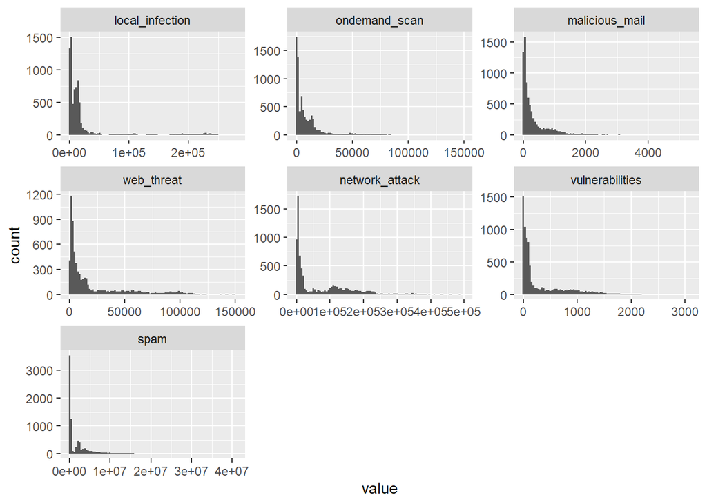

```r
ggplot(c.h) + geom_histogram(aes(x=value), bins=100) + facet_wrap(facets = vars(variable), nrow=3, ncol=3, scales = "free")
```

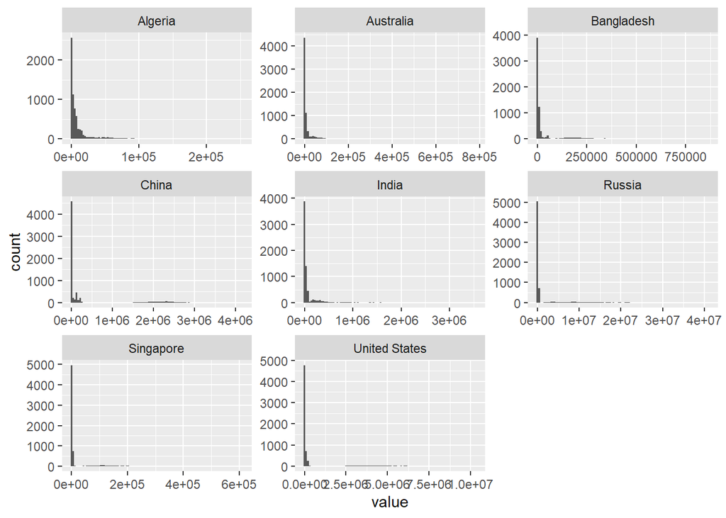

```r
ggplot(c.h) + geom_histogram(aes(x=value), bins=100) + facet_wrap(facets = vars(country), nrow=3, ncol=3, scales = "free")
```

```r
prop.table(table(c.h$variable, is.na(c.h$value)), margin = 1)
```

```
##
##                        FALSE       TRUE
##   local_infection 0.96825397 0.03174603
##   ondemand_scan   0.96825397 0.03174603
##   malicious_mail  0.96812996 0.03187004
##   web_threat      0.84920635 0.15079365
##   network_attack  0.96825397 0.03174603
##   vulnerabilities 0.96726190 0.03273810
##   spam            0.97619048 0.02380952
```

There isn’t much we can glean from the histograms per threat, per country or per hour, because the absolute values differ greatly for these 3 variables. Dicing is needed to perceive the trends.

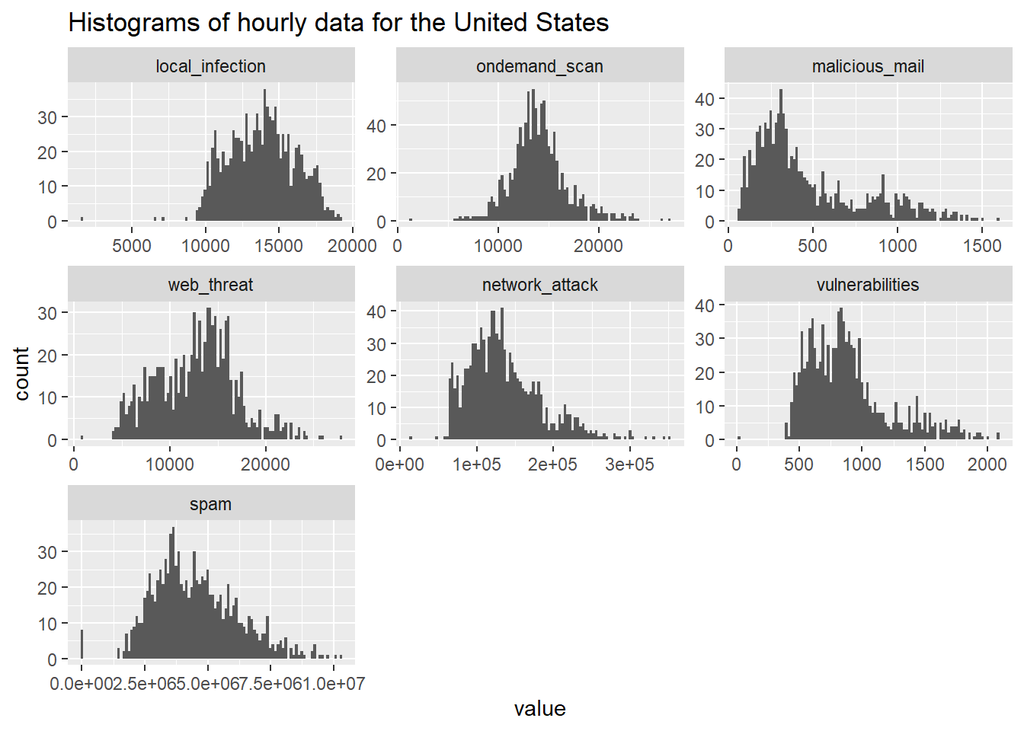

```r
# Plotting data for 3 selected countries

ggplot(c.h[c.h$country == "United States", ]) + geom_histogram(aes(x=value), bins=100) + facet_wrap(facets = vars(variable), nrow=3, ncol=3, scales = "free") + labs(title="Histograms of hourly data for the United States")
```

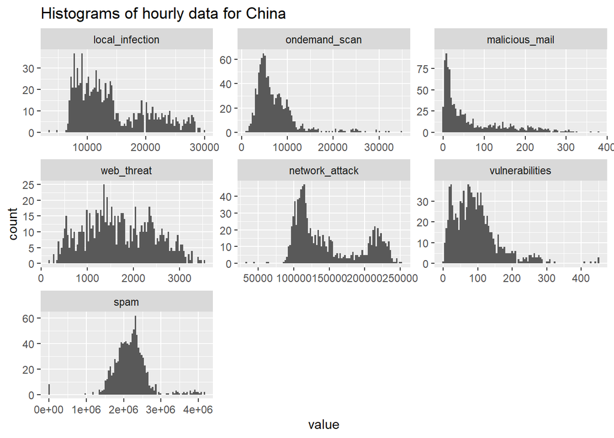

```r
ggplot(c.h[c.h$country == "China", ]) + geom_histogram(aes(x=value), bins=100) + facet_wrap(facets = vars(variable), nrow=3, ncol=3, scales = "free") + labs(title="Histograms of hourly data for China")
```

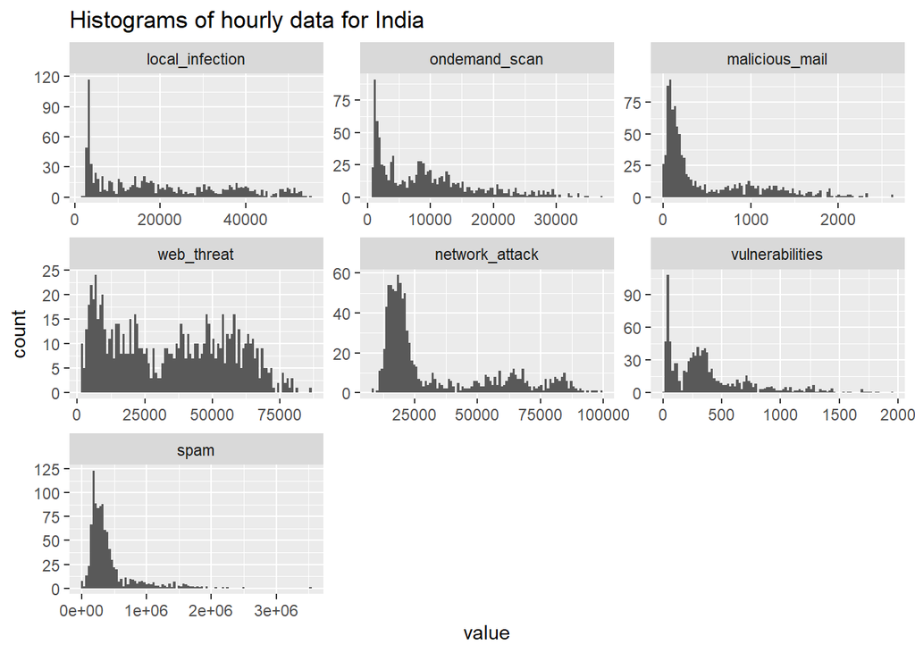

```r
ggplot(c.h[c.h$country == "India", ]) + geom_histogram(aes(x=value), bins=100) + facet_wrap(facets = vars(variable), nrow=3, ncol=3, scales = "free") + labs(title="Histograms of hourly data for India")
```

The shapes of data differ significantly between countries - it seems there are different patterns of attack depending on the country. We can explore this further.

```r
na.webthreat <- filter(compiled.hourly, is.na(compiled.hourly$web_threat))
na.localinfection <- filter(compiled.hourly, is.na(compiled.hourly$local_infection))

dim(na.webthreat)
```

```
## [1] 1216   10
```

```r
tail(na.webthreat)
```

```
## # A tibble: 6 x 10
##   date        hour country local_infection ondemand_scan malicious_mail
##   <date>     <int> <chr>             <dbl>         <dbl>          <dbl>
## 1 2020-09-20    18 United~           12166          9349            318
## 2 2020-09-20    19 United~           11650          9233            291
## 3 2020-09-20    20 United~           12407          9990            281
## 4 2020-09-20    21 United~           12395          9397            316
## 5 2020-09-20    22 United~           12140         10619            317
## 6 2020-09-20    23 United~           12159         13524            278
## # ... with 4 more variables: web_threat <dbl>, network_attack <dbl>,
## #   vulnerabilities <dbl>, spam <dbl>
```

```r
na.webthreat[na.webthreat$country == "China",]
```

```
## # A tibble: 152 x 10
##    date        hour country local_infection ondemand_scan malicious_mail
##    <date>     <int> <chr>             <dbl>         <dbl>          <dbl>
##  1 2020-08-10    22 China                NA            NA             NA
##  2 2020-08-10    23 China                NA            NA             NA
##  3 2020-08-11     0 China                NA            NA             NA
##  4 2020-08-11     1 China                NA            NA             NA
##  5 2020-08-11     2 China                NA            NA             NA
##  6 2020-08-11     3 China                NA            NA             NA
##  7 2020-08-11     4 China                NA            NA             NA
##  8 2020-08-11     5 China                NA            NA             NA
##  9 2020-08-23     0 China             12733          5230             15
## 10 2020-08-23     1 China             14413          5567              7
## # ... with 142 more rows, and 4 more variables: web_threat <dbl>,
## #   network_attack <dbl>, vulnerabilities <dbl>, spam <dbl>
```

### 4. Imputation of Missing Values

To impute the missing data in the hourly dataset, first I tried using the imputeTS package to do the imputation automatically. However, this did not result in reasonable values - some were even negative.

Looking at the documentation for imputeTS, this seems to be because the formulae for imputation do not take into account seasonal variation.

```r
## Use imputeTS package on segment of the data (web threats in China)
statsNA(compiled.hourly[compiled.hourly$country == "China", ]$web_threat)
```

```
## [1] "Length of time series:"
## [1] 1008
## [1] "-------------------------"
## [1] "Number of Missing Values:"
## [1] 152
## [1] "-------------------------"
## [1] "Percentage of Missing Values:"
## [1] "15.1%"
## [1] "-------------------------"
## [1] "Number of Gaps:"
## [1] 5
## [1] "-------------------------"
## [1] "Average Gap Size:"
## [1] 30.4
## [1] "-------------------------"
```

[output cut: 19 more lines]

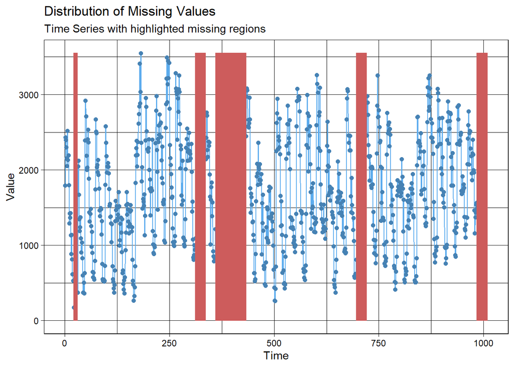

```r
# Useful summary of NA values

ggplot_na_distribution(compiled.hourly[compiled.hourly$country == "China","web_threat"])
```

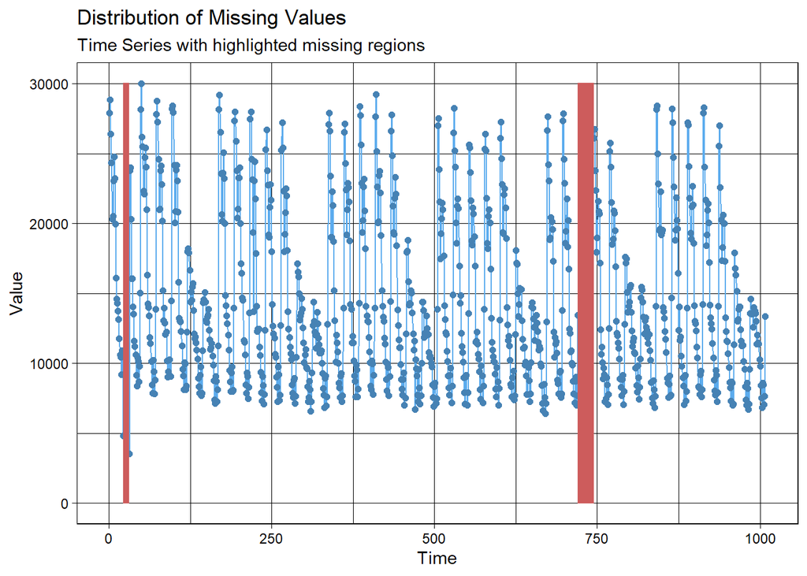

```r
# Useful visual representation of NA values in the time series

ggplot_na_distribution(compiled.hourly[compiled.hourly$country == "China","local_infection"])
```

There are many more missing values in web threats than in other types of threats.

ImputeTS has a few algorithms for imputing missing data, “stine”, “spline” and “linear”. Each of these are tried:

```r
data_impute_stine <- na_interpolation(compiled.hourly, option = "stine") # not very accurate

data_impute_spline <- na_interpolation(compiled.hourly, option = "spline") # very inaccurate - high negative values

data_impute_linear <- na_interpolation(compiled.hourly, option = "linear") # very inaccurate

summary(data_impute_stine)
```

```
##       date                 hour         country          local_infection
##  Min.   :2020-08-10   Min.   : 0.00   Length:8064        Min.   :    37
##  1st Qu.:2020-08-20   1st Qu.: 5.75   Class :character   1st Qu.:  2344
##  Median :2020-08-30   Median :11.50   Mode  :character   Median :  9457
##  Mean   :2020-08-30   Mean   :11.50                      Mean   : 28595
##  3rd Qu.:2020-09-10   3rd Qu.:17.25                      3rd Qu.: 16467
##  Max.   :2020-09-20   Max.   :23.00                      Max.   :279983
##  ondemand_scan    malicious_mail     web_threat     network_attack
##  Min.   :    10   Min.   :   0.0   Min.   :    93   Min.   :   213
##  1st Qu.:  1025   1st Qu.:  51.0   1st Qu.:  2648   1st Qu.:  4743
##  Median :  4693   Median : 148.0   Median :  9346   Median : 18512
##  Mean   : 10989   Mean   : 362.9   Mean   : 22386   Mean   : 69474
##  3rd Qu.: 13336   3rd Qu.: 424.0   3rd Qu.: 33465   3rd Qu.:121675
##  Max.   :148912   Max.   :5344.0   Max.   :150826   Max.   :496537
##  vulnerabilities        spam
##  Min.   : -13.91   Min.   :       0
##  1st Qu.:  24.00   1st Qu.:   84500
##  Median :  99.00   Median :  268500
##  Mean   : 324.62   Mean   : 2160583
##  3rd Qu.: 494.50   3rd Qu.: 2565000
##  Max.   :3092.00   Max.   :40955500
```

```r
summary(data_impute_spline)
```

```
##       date                 hour         country          local_infection
##  Min.   :2020-08-10   Min.   : 0.00   Length:8064        Min.   :-215253
##  1st Qu.:2020-08-20   1st Qu.: 5.75   Class :character   1st Qu.:   2325
##  Median :2020-08-30   Median :11.50   Mode  :character   Median :   9569
##  Mean   :2020-08-30   Mean   :11.50                      Mean   :  28585
##  3rd Qu.:2020-09-10   3rd Qu.:17.25                      3rd Qu.:  17027
##  Max.   :2020-09-20   Max.   :23.00                      Max.   : 279983
##  ondemand_scan    malicious_mail      web_threat     network_attack
##  Min.   :-63049   Min.   :-2554.0   Min.   : -6663   Min.   :-904022
##  1st Qu.:  1004   1st Qu.:   43.0   1st Qu.:  2628   1st Qu.:   4419
##  Median :  4694   Median :  136.0   Median :  9144   Median :  17263
##  Mean   : 11539   Mean   :  330.1   Mean   : 46731   Mean   :  56558
##  3rd Qu.: 13499   3rd Qu.:  423.0   3rd Qu.: 42752   3rd Qu.: 121277
##  Max.   :148912   Max.   : 5344.0   Max.   :675476   Max.   : 496537
##  vulnerabilities        spam
##  Min.   :-3590.1   Min.   :       0
##  1st Qu.:   21.0   1st Qu.:   85375
##  Median :   92.0   Median :  272250
##  Mean   :  272.3   Mean   : 2626782
##  3rd Qu.:  491.5   3rd Qu.: 2694500
##  Max.   : 3092.0   Max.   :40955500
```

```r
summary(data_impute_linear)
```

```
##       date                 hour         country          local_infection
##  Min.   :2020-08-10   Min.   : 0.00   Length:8064        Min.   :    37
##  1st Qu.:2020-08-20   1st Qu.: 5.75   Class :character   1st Qu.:  2348
##  Median :2020-08-30   Median :11.50   Mode  :character   Median :  9170
##  Mean   :2020-08-30   Mean   :11.50                      Mean   : 28584
##  3rd Qu.:2020-09-10   3rd Qu.:17.25                      3rd Qu.: 16482
##  Max.   :2020-09-20   Max.   :23.00                      Max.   :279983
##  ondemand_scan    malicious_mail     web_threat     network_attack
##  Min.   :    10   Min.   :   0.0   Min.   :    93   Min.   :   213
##  1st Qu.:  1027   1st Qu.:  51.0   1st Qu.:  2762   1st Qu.:  4862
##  Median :  4664   Median : 147.0   Median : 10756   Median : 19792
##  Mean   : 10865   Mean   : 363.5   Mean   : 22071   Mean   : 70848
##  3rd Qu.: 13046   3rd Qu.: 424.0   3rd Qu.: 29560   3rd Qu.:123494
##  Max.   :148912   Max.   :5344.0   Max.   :150826   Max.   :496537
##  vulnerabilities       spam
##  Min.   :   0.0   Min.   :       0
##  1st Qu.:  25.0   1st Qu.:   85375
##  Median :  98.0   Median :  271250
##  Mean   : 325.6   Mean   : 2155151
##  3rd Qu.: 518.0   3rd Qu.: 2561125
##  Max.   :3092.0   Max.   :40955500
```

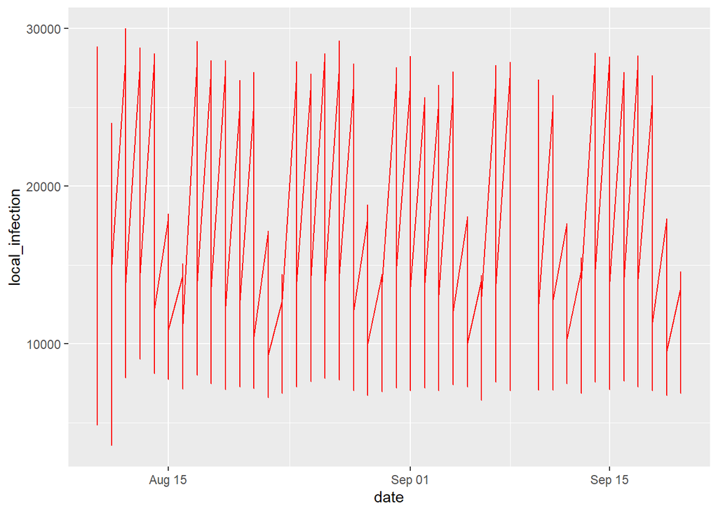

```r
ggplot() +
  geom_line(data = compiled.hourly[compiled.hourly$country == "China",],
            aes(x = date, y = local_infection), color = "red")
```

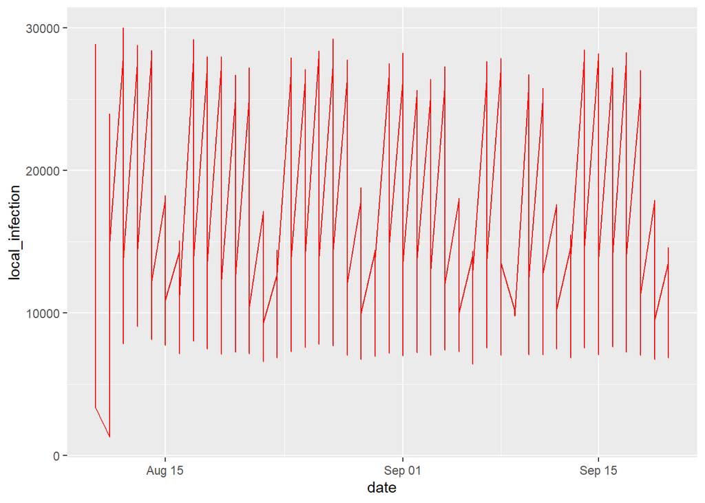

```r
ggplot() +
  geom_line(data = data_impute_stine[data_impute_stine$country == "China",],
            aes(x = date, y = local_infection), color = "red")
```

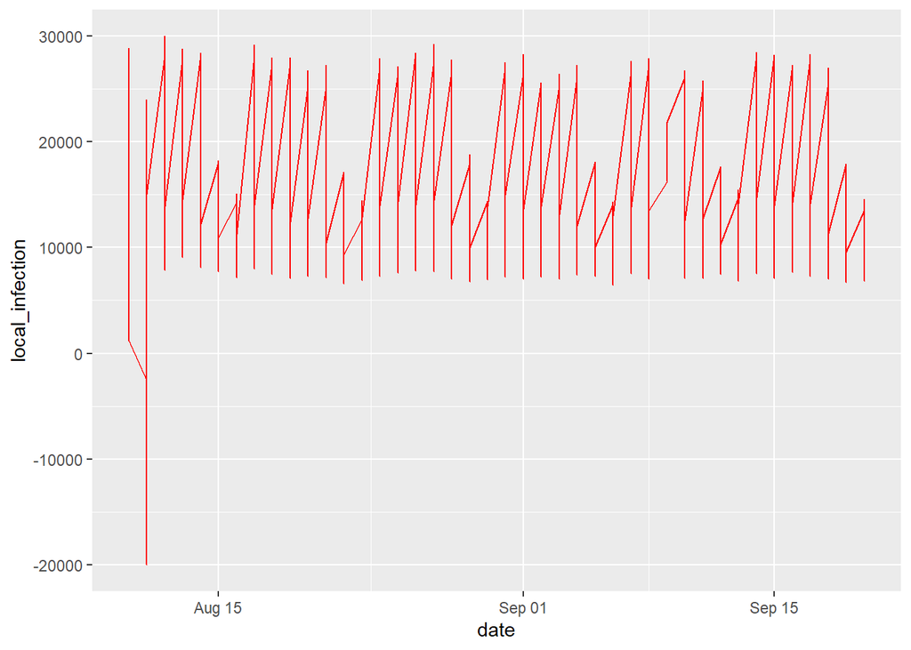

```r
ggplot() +
  geom_line(data = data_impute_spline[data_impute_spline$country == "China",],
            aes(x = date, y = local_infection), color = "red")
```

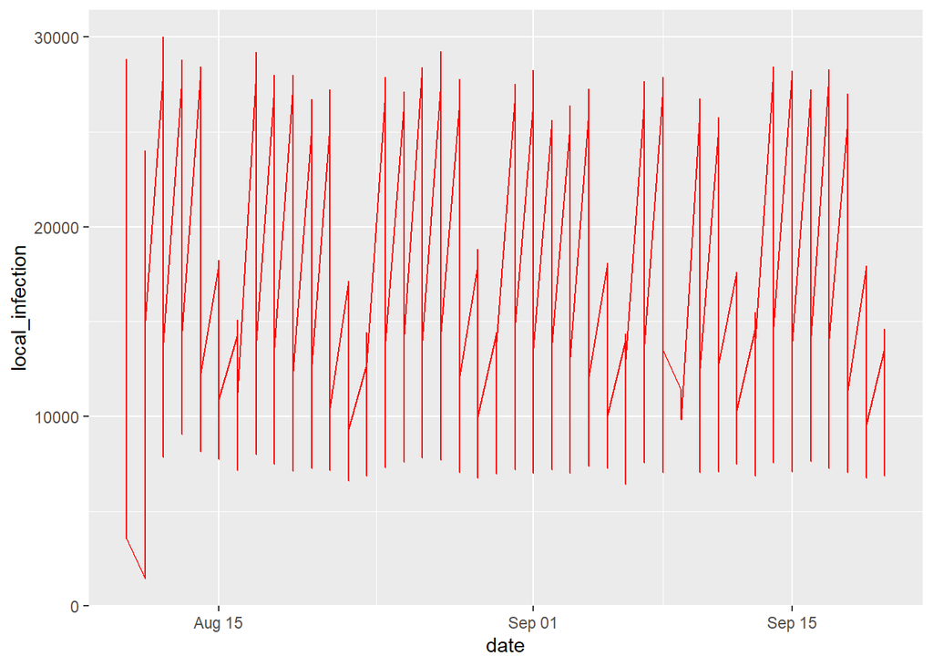

```r
ggplot() +
  geom_line(data = data_impute_linear[data_impute_linear$country == "China",],
            aes(x = date, y = local_infection), color = "red")
```

Each of the methods does not recognize the seasonal trend, but tries to draw a line to extrapolate from, or connect, neighbouring values. This leads to negative numbers in certain cases.

```r
# Impute missing hours manually using same hour of same day in previous weeks

# impute for 10 Aug 10pm to 11pm
mondays <- compiled.hourly[compiled.hourly$date %in% as.Date(c("2020-08-17", "2020-08-24", "2020-08-31", "2020-09-07")) & compiled.hourly$hour %in% c(22, 23), ]

monday_new <- mondays %>%
  group_by(country, hour) %>%
  summarise(local_infection = mean(local_infection),
            ondemand_scan = mean(ondemand_scan),
            malicious_mail = mean(malicious_mail),
            web_threat = mean(web_threat),
            network_attack = mean(network_attack),
            vulnerabilities = mean(vulnerabilities),
            spam = mean(spam))
monday_new$date <- as.Date("2020-08-10")
monday_new <- monday_new[, c(10, 2, 1, 3:9)]
monday_new <- as.data.frame(monday_new)

hourly2 <- filter(compiled.hourly, !(compiled.hourly$date == as.Date("2020-08-10") & compiled.hourly$hour %in% c(22,23)))

hourly2 <- rbind(hourly2, monday_new)
hourly2 <- hourly2[order(hourly2$country, hourly2$date),]
head(hourly2,40)
```

```
## # A tibble: 40 x 10
##    date        hour country local_infection ondemand_scan malicious_mail
##    <date>     <int> <chr>             <dbl>         <dbl>          <dbl>
##  1 2020-08-10     0 Algeria            3056          1503              7
##  2 2020-08-10     1 Algeria            2617          1057              3
##  3 2020-08-10     2 Algeria            2770           721             10
##  4 2020-08-10     3 Algeria            2481           484             19
##  5 2020-08-10     4 Algeria            2158           726              6
##  6 2020-08-10     5 Algeria            2313           622             23
##  7 2020-08-10     6 Algeria            4940          1338             43
##  8 2020-08-10     7 Algeria           14633          7305            358
##  9 2020-08-10     8 Algeria           15123         14643            348
## 10 2020-08-10     9 Algeria           14787         11857            344
## # ... with 30 more rows, and 4 more variables: web_threat <dbl>,
## #   network_attack <dbl>, vulnerabilities <dbl>, spam <dbl>
```

```r
# impute for 11 Aug midnight to 5am

tuesdays <- compiled.hourly[compiled.hourly$date %in% as.Date(c("2020-08-18", "2020-08-25", "2020-09-01", "2020-09-08")) &
                  compiled.hourly$hour %in% c(0, 1, 2, 3, 4, 5), ]

tuesday_new <- tuesdays %>%
  group_by(country, hour) %>%
  summarise(local_infection = mean(local_infection),
            ondemand_scan = mean(ondemand_scan),
            malicious_mail = mean(malicious_mail),
            web_threat = mean(web_threat),
            network_attack = mean(network_attack),
            vulnerabilities = mean(vulnerabilities),
            spam = mean(spam))
tuesday_new$date <- as.Date("2020-08-11")
tuesday_new <- tuesday_new[, c(10, 2, 1, 3:9)]
tuesday_new <- as.data.frame(tuesday_new)

hourly3 <- filter(hourly2, !(hourly2$date == as.Date("2020-08-11") & hourly2$hour %in% c(0,1,2,3,4,5)))

hourly3 <- rbind(hourly3, tuesday_new)
hourly3 <- hourly3[order(hourly3$country, hourly3$date, hourly3$hour),]
```

```r
## There are too many missing web threat values - remove web threat column

hourly3$web_threat <- NULL

## Impute all values for 9 Sept (Wednesday)
wed <- hourly3[hourly3$date %in% as.Date(c("2020-08-12", "2020-08-19",
                                         "2020-08-26", "2020-09-02")), ]
wed_new <- wed %>%
  group_by(country, hour) %>%
  summarise(local_infection = mean(local_infection),
            ondemand_scan = mean(ondemand_scan),
            malicious_mail = mean(malicious_mail),
            network_attack = mean(network_attack),
            vulnerabilities = mean(vulnerabilities),
            spam = mean(spam))
wed_new$date <- as.Date("2020-09-09")
wed_new <- wed_new[, c(9, 2, 1, 3:8)]
wed_new <- as.data.frame(wed_new)

hourly4 <- filter(hourly3, !(hourly3$date == as.Date("2020-09-09")))
hourly4 <- rbind(hourly4, wed_new)
hourly4 <- hourly4[order(hourly4$country, hourly4$date),]

summary(hourly4)
```

```
##       date                 hour         country          local_infection
##  Min.   :2020-08-10   Min.   : 0.00   Length:8064        Min.   :    37
##  1st Qu.:2020-08-20   1st Qu.: 5.75   Class :character   1st Qu.:  2318
##  Median :2020-08-30   Median :11.50   Mode  :character   Median :  9204
##  Mean   :2020-08-30   Mean   :11.50                      Mean   : 29193
##  3rd Qu.:2020-09-10   3rd Qu.:17.25                      3rd Qu.: 16803
##  Max.   :2020-09-20   Max.   :23.00                      Max.   :279983
##
##  ondemand_scan      malicious_mail   network_attack   vulnerabilities
##  Min.   :    10.0   Min.   :   0.0   Min.   :   213   Min.   :   0.0
##  1st Qu.:   993.8   1st Qu.:  50.0   1st Qu.:  4772   1st Qu.:  23.0
##  Median :  4549.5   Median : 147.0   Median : 18679   Median :  95.0
##  Mean   : 10958.4   Mean   : 372.4   Mean   : 70881   Mean   : 325.9
##  3rd Qu.: 13093.2   3rd Qu.: 447.5   3rd Qu.:124208   3rd Qu.: 524.0
##  Max.   :148912.0   Max.   :5344.0   Max.   :496537   Max.   :3092.0
##                     NA's   :1                         NA's   :8
##       spam
##  Min.   :       0
##  1st Qu.:   86000
##  Median :  264750
##  Mean   : 2179460
##  3rd Qu.: 2547625
##  Max.   :40955500
##
```

```r
# Checking remaining NAs - should mostly be 0s
new_DF <- hourly4[rowSums(is.na(hourly4)) > 0,]
new_DF
```

```
## # A tibble: 9 x 9
##   date        hour country local_infection ondemand_scan malicious_mail
##   <date>     <int> <chr>             <dbl>         <dbl>          <dbl>
## 1 2020-08-11    22 Bangla~            1074           349             38
## 2 2020-08-11    23 Bangla~            1077           440             39
## 3 2020-08-13    23 Bangla~             948           204             16
## 4 2020-08-29     0 Bangla~            1052           206             20
## 5 2020-08-16    23 China             11244          4500             NA
## 6 2020-08-11    23 Singap~             210            83             88
## 7 2020-08-13    21 Singap~             109            46             66
## 8 2020-08-13    22 Singap~              90            84             70
## 9 2020-08-13    23 Singap~             188            75            115
## # ... with 3 more variables: network_attack <dbl>, vulnerabilities <dbl>,
## #   spam <dbl>
```

```r
# Replace remaining NAs with 0 - likely to be genuine zero values
hourly4[is.na(hourly4)] <- 0
length(hourly4[is.na(hourly4)]) # no more NAs
```

```
## [1] 0
```

While it would be ideal to obtain the missing values in the daily data from the hourly data, this is not possible because of differences between the two datasets, namely:

1. Hourly data was only collected for 8 countries, while the daily data was collected for 215 countries.
2. Hourly data is presented as absolute numbers, while daily data is presented as proportions (of the population of Kaspersky users in that country who experienced the threat).

```r
# Order hourly data by country then by date
hourly4 <- hourly4[order(hourly4$country, hourly4$date),]
```

This concludes part one, the compilation and pre-processing of Kaspersky data. In the next part, we will do time series analysis of the data.

```r
write.csv(daily.filtered, "cleaned/dailydata.csv")
write.csv(hourly4, "cleaned/hourlydata.csv")
```

This project was carried out as part of the fundamental certificates in Analytics Project Management and Business Analytics Practice in the NUS MTech program. It is my portion of a self-directed group project on the wider topic of cybersecurity threats and attacks.